# Hapmap update

February 2018

## Hapmap update

So far…

- Draft completed
- Jon and Mirte been through it

To do…

- Sort pitch
- Decide on final analyses
- Write up and submit

## Islands of speciation

Turner & Hahn 2005, *PLoS Biol.*

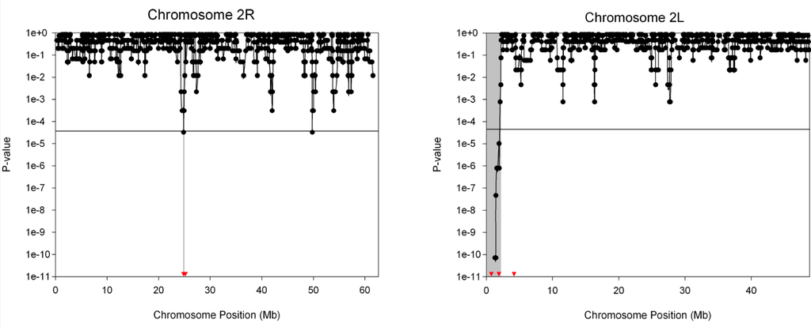

## Islands of speciation

[figure not shown]

## Islands of speciation

- Are islands of speciation real?
- Islands of speciation/differentiation/divergence?
- Is gene flow required for islands to form?
- Is it all reduced recombination?
- Should we use \(F_{ST}\) or \(d_{xy}\) to measure divergence

## Beyond islands of speciation

How does divergence build up across the genome and how do different evolutionary forces contribute to this?

- Selection
- Gene flow
- Drift
- Recombination

**Few studies on build up of genomic divergence along known colonisation routes**

## Hapmap samples

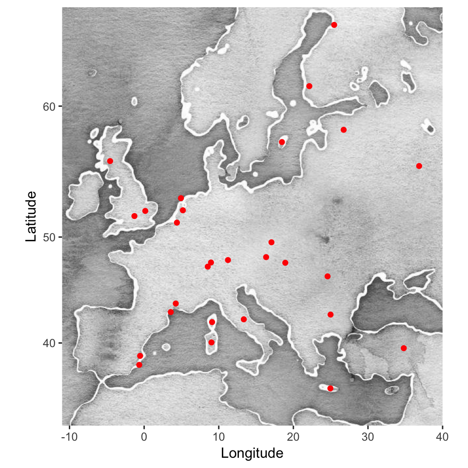

## Hapmap aims

- Determine colonisation route of GT throughout Europe
- Look at how divergence across the genome accumulates along the colonisation route
- Understand where (and why?) selection has operated (both "where" in the genome and "where" in Europe)

## Phylogeography

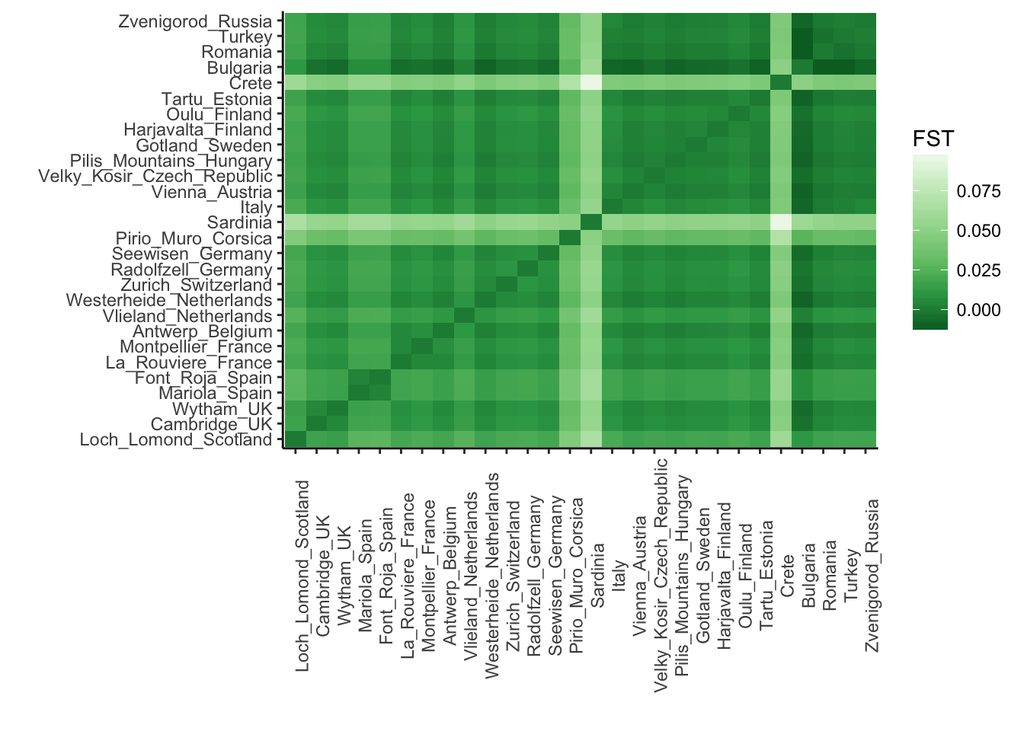

## Phylogeography

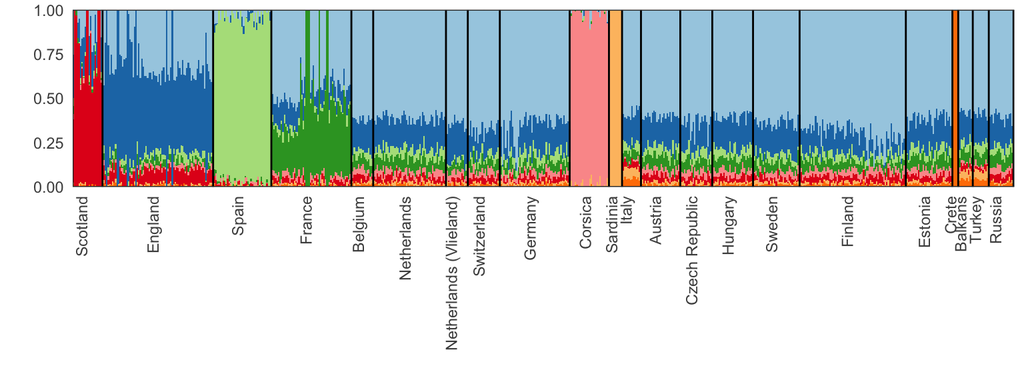

## Phylogeography

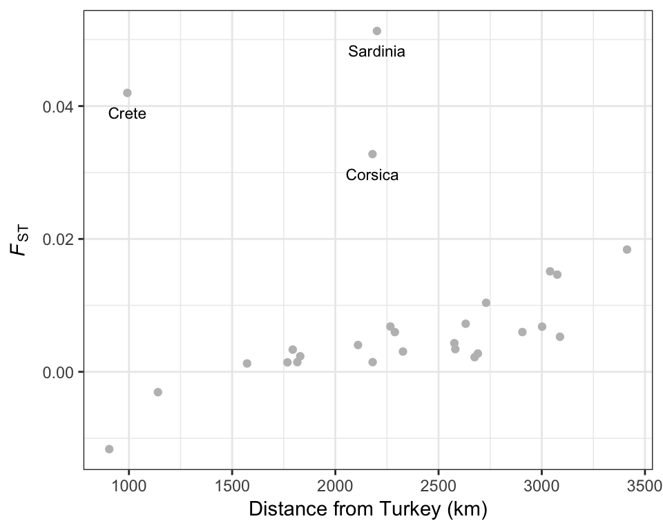

## Genomic landscape of differentiation

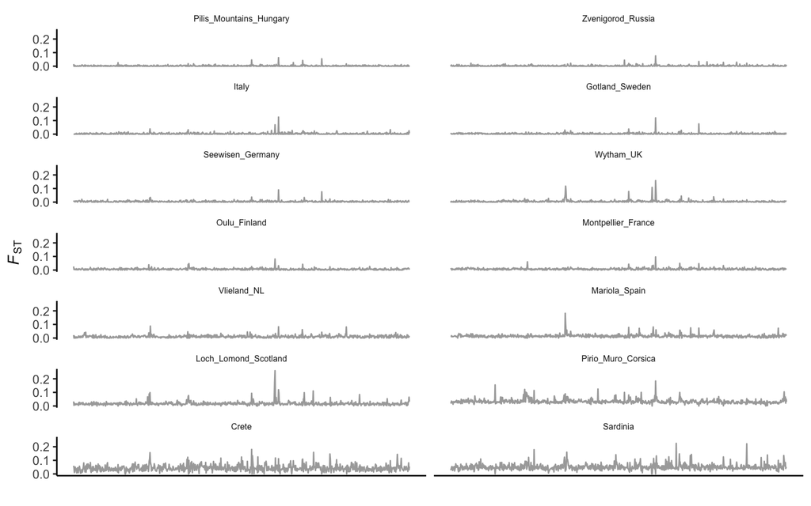

## Next steps

- More phylogeography needed?
- Comparisons with Turkey a good way to go?
- Sample size for Turkey (11) too low?
- Quantify overlap in outlier regions
- Associate with recombination rates